# hmc0110’s Report

HealthyReal

2024-03-13

#### “다이어트”라는 목적을 가지고 HealthyReal를 이용중이신, **hmc0110**님의 2024년 03월 보고서는 다음과 같습니다.

#### 1. 추천을 많이 받았던 음식

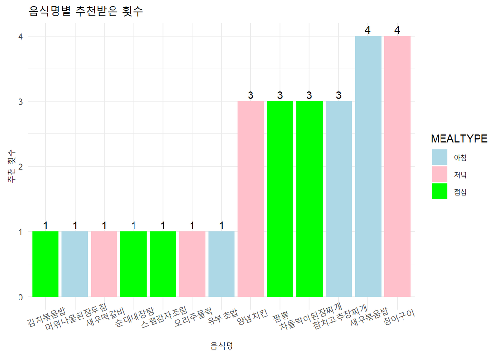

**hmc0110**님은

- 아침 : 새우볶음밥
- 점심 : 차돌박이된장찌개, 짬뽕
- 저녁 : 장어구이

을 가장 많이 추천을 받으셨으며, 자사에 식사별로 가장 많은 섭취 인증하신 음식은 아래와 같습니다.

- 아침 : 간장게장,시래기국
- 점심 : 유부초밥
- 저녁 : 양념치킨

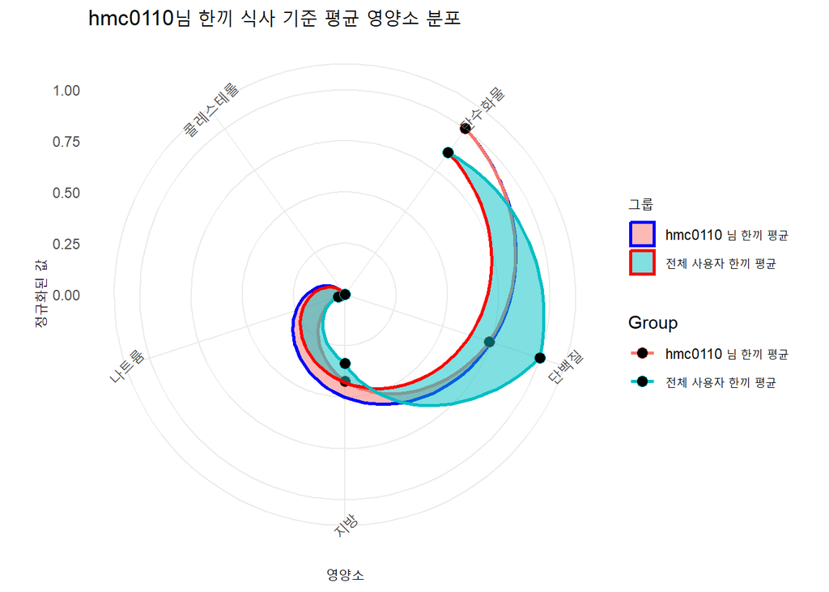

##### **hmc0110**님은 전체 사용자의 한끼 평균 식사보다

- 탄수화물 섭취량이 비교적 높은 편입니다.
- 단백질 섭취량이 비교적 낮은 편입니다.
- 지방 섭취량이 비교적 높은 편입니다.
- 나트륨 섭취량이 비교적 낮은 편입니다.
- 콜레스테롤 섭취량이 비교적 높은 편입니다.

#### 2. 추천을 많이 요청한 운동 부위

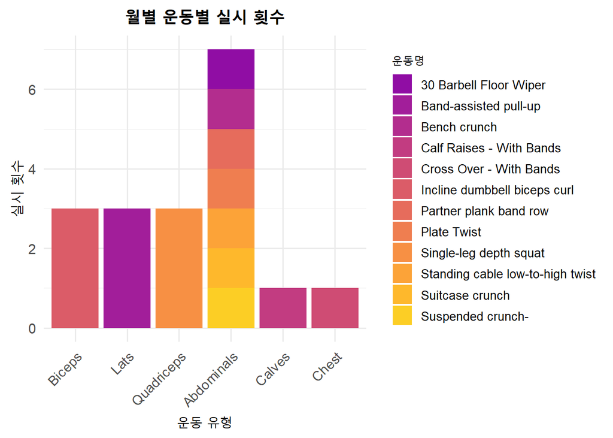

#### 3. hmc0110님 HealthyReal 이행률

hmc0110님은 현재 13일 중 6일을 이행률 측정에 참여하셨으며, 그에 대한 달성 수치 및 그래프는 다음과 같습니다.

- 운동은 72.22%를 달성
- 음식은 88.89%를 달성
- 전체 달성 확률은 80.555%

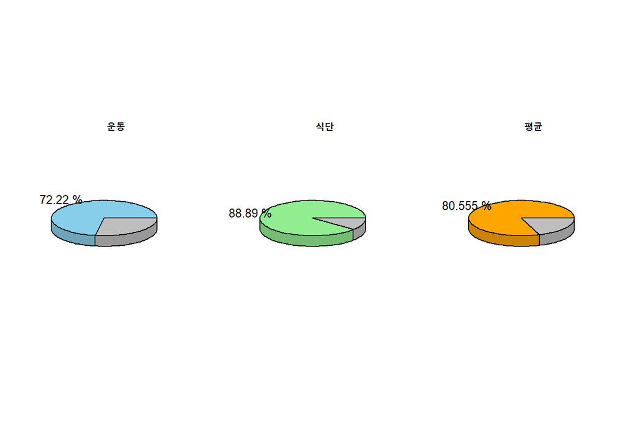

#### 4. hmc0110님 인바디 시계열 그래프

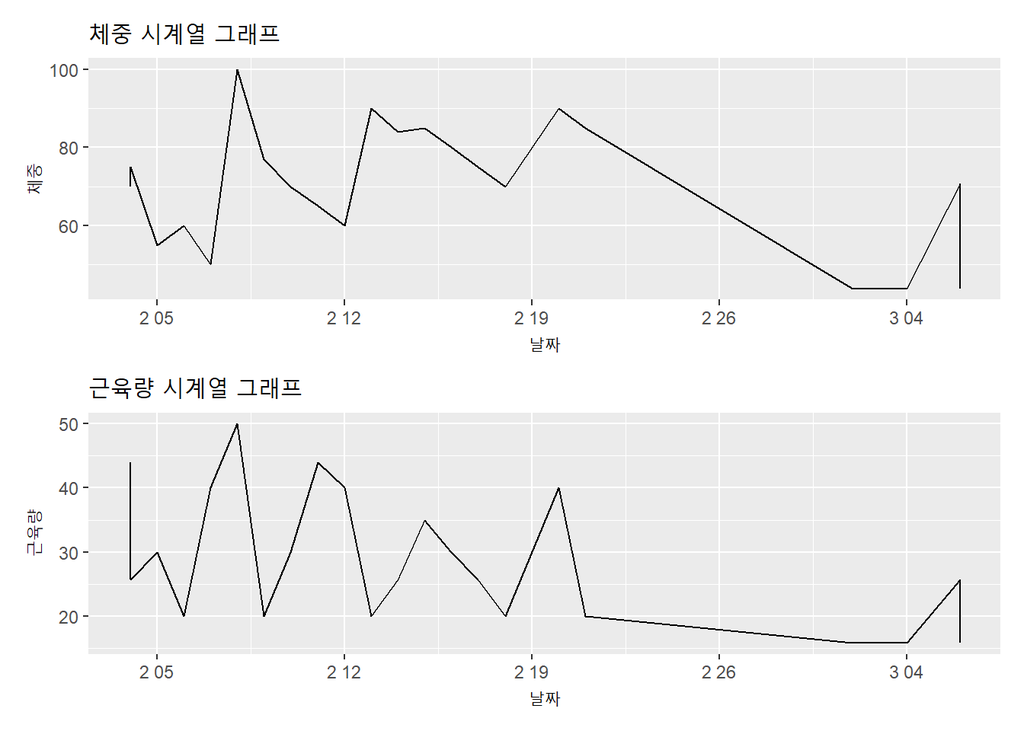

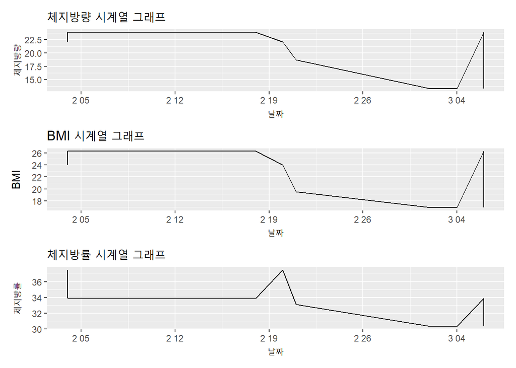

#### 5. hmc0110님 2024년 03월 종합 감정

##### **hmc0110님 2024년 03월 행복 지수 : 75**

요즘 평소보다 좋은 일들이 많은 것 같네요!  
그거 아시나요? 앞으로는 지금보다 더 좋은 일들이 더 많으실꺼예요!